# **Music Recommendation System**

## **Milestone 1**

## **Problem Definition**

**The context:** Why is this problem important to solve?

- With the ever-increasing volume of songs becoming available on the Internet,searching for songs of interest has become a tedious task in itself for users.
- Every Internet based company wants to increase customer time spent on their platform and increase company's revenue.
- By using smart recommendation systems(one like Spotify) that can recommend songs based on users’ likes/dislikes among millions of customers and billions of songs would be Win-Win for customers and internet based companies.

**The objectives:** What is the intended goal?

- Build a recommendation system to propose the top 10 songs for a user based on the likelihood of them listening to those songs.
- Build recommendation system to increase customer time spent on their platform and increase company's revenue.

**The key questions:** What are the key questions that need to be answered?

- Main question is to figure out what kind of content customers are most likely to consume.
- What are the most popular songs to suggest a new user.
- Identify songs based on ratings, reviews, artists, genre, year released etc.
- Identify songs for existing users that are similar to their listening history.
- Identify users who have similar tastes in music and recommend similar songs to them.

**The problem formulation:** What are we trying to solve using data science?

- Build recommendation system using different models.
- For new users who have not history/data, we build recommendation systems based on populatrity and recommend popular songs.
- For existing users we build recommendation system models using collaborative filtering, matrix factorization and other methods. We then compare the efficiancy of the models and choose the best one to recommend songs to users.

## **Data Dictionary**

The core data is the Taste Profile Subset released by the Echo Nest as part of the Million Song Dataset. There are two files in this dataset. The first file contains the details about the song id, titles, release, artist name, and the year of release. The second file contains the user id, song id, and the play count of users.

song_data

song_id - A unique id given to every song

title - Title of the song

Release - Name of the released album

Artist_name - Name of the artist

year - Year of release

count_data

user _id - A unique id given to the user

song_id - A unique id given to the song

play_count - Number of times the song was played

## **Data Source**

http://millionsongdataset.com/

## **Important Notes**

- This notebook can be considered a guide to refer to while solving the problem. The evaluation will be as per the Rubric shared for each Milestone. Unlike previous courses, it does not follow the pattern of the graded questions in different sections. This notebook would give you a direction on what steps need to be taken to get a feasible solution to the problem. Please note that this is just one way of doing this. **There can be other 'creative' ways to solve the problem, and we encourage you to feel free and explore them as an 'optional' exercise**.
- In the notebook, there are markdown cells called Observations and Insights. It is a good practice to provide observations and extract insights from the outputs.
- The naming convention for different variables can vary. **Please consider the code provided in this notebook as a sample code.**
- All the outputs in the notebook are just for reference and can be different if you follow a different approach.
- There are sections called **Think About It** in the notebook that will help you get a better understanding of the reasoning behind a particular technique/step. Interested learners can take alternative approaches if they want to explore different techniques.

### **Importing Libraries and the Dataset**

```python
# Mounting the drive
from google.colab import drive
drive.mount('/content/drive')
```

```python
# Used to ignore the warning given as output of the code
import warnings
warnings.filterwarnings('ignore')

# Basic libraries of python for numeric and dataframe computations
import numpy as np
import pandas as pd

# Basic library for data visualization
import matplotlib.pyplot as plt

# Slightly advanced library for data visualization
import seaborn as sns

# To compute the cosine similarity between two vectors
from sklearn.metrics.pairwise import cosine_similarity

# A dictionary output that does not raise a key error
from collections import defaultdict

# A performance metrics in sklearn
from sklearn.metrics import mean_squared_error
```

### **Load the dataset**

```python
# Importing the datasets
count_df = pd.read_csv('/content/drive/MyDrive/ADSP/Capstone/count_data.csv')
song_df = pd.read_csv('/content/drive/MyDrive/ADSP/Capstone/song_data.csv')
```

### **Understanding the data by viewing a few observations**

```python
# See top 10 records of count_df data
count_df.head(n=10)
```

|  | Unnamed: 0 | user_id | song_id | play_count |
| --- | --- | --- | --- | --- |
| 0 | 0 | b80344d063b5ccb3212f76538f3d9e43d87dca9e | SOAKIMP12A8C130995 | 1 |
| 1 | 1 | b80344d063b5ccb3212f76538f3d9e43d87dca9e | SOBBMDR12A8C13253B | 2 |
| 2 | 2 | b80344d063b5ccb3212f76538f3d9e43d87dca9e | SOBXHDL12A81C204C0 | 1 |
| 3 | 3 | b80344d063b5ccb3212f76538f3d9e43d87dca9e | SOBYHAJ12A6701BF1D | 1 |
| 4 | 4 | b80344d063b5ccb3212f76538f3d9e43d87dca9e | SODACBL12A8C13C273 | 1 |
| 5 | 5 | b80344d063b5ccb3212f76538f3d9e43d87dca9e | SODDNQT12A6D4F5F7E | 5 |
| 6 | 6 | b80344d063b5ccb3212f76538f3d9e43d87dca9e | SODXRTY12AB0180F3B | 1 |
| 7 | 7 | b80344d063b5ccb3212f76538f3d9e43d87dca9e | SOFGUAY12AB017B0A8 | 1 |
| 8 | 8 | b80344d063b5ccb3212f76538f3d9e43d87dca9e | SOFRQTD12A81C233C0 | 1 |
| 9 | 9 | b80344d063b5ccb3212f76538f3d9e43d87dca9e | SOHQWYZ12A6D4FA701 | 1 |

```python
# See top 10 records of song_df data
song_df.head(n=10)
```

|  | song_id | title | release | artist_name | year |
| --- | --- | --- | --- | --- | --- |
| 0 | SOQMMHC12AB0180CB8 | Silent Night | Monster Ballads X-Mas | Faster Pussy cat | 2003 |
| 1 | SOVFVAK12A8C1350D9 | Tanssi vaan | Karkuteillä | Karkkiautomaatti | 1995 |
| 2 | SOGTUKN12AB017F4F1 | No One Could Ever | Butter | Hudson Mohawke | 2006 |
| 3 | SOBNYVR12A8C13558C | Si Vos Querés | De Culo | Yerba Brava | 2003 |
| 4 | SOHSBXH12A8C13B0DF | Tangle Of Aspens | Rene Ablaze Presents Winter Sessions | Der Mystic | 0 |
| 5 | SOZVAPQ12A8C13B63C | Symphony No. 1 G minor "Sinfonie Serieuse"/All... | Berwald: Symphonies Nos. 1/2/3/4 | David Montgomery | 0 |
| 6 | SOQVRHI12A6D4FB2D7 | We Have Got Love | Strictly The Best Vol. 34 | Sasha / Turbulence | 0 |
| 7 | SOEYRFT12AB018936C | 2 Da Beat Ch'yall | Da Bomb | Kris Kross | 1993 |
| 8 | SOPMIYT12A6D4F851E | Goodbye | Danny Boy | Joseph Locke | 0 |
| 9 | SOJCFMH12A8C13B0C2 | Mama_ mama can't you see ? | March to cadence with the US marines | The Sun Harbor's Chorus-Documentary Recordings | 0 |

### **Let us check the data types and and missing values of each column**

```python
# See the info of the count_df data
count_df.info()
```

```
<class 'pandas.core.frame.DataFrame'>
RangeIndex: 2000000 entries, 0 to 1999999
Data columns (total 4 columns):
 #   Column      Dtype
---  ------      -----
 0   Unnamed: 0  int64
 1   user_id     object
 2   song_id     object
 3   play_count  int64
dtypes: int64(2), object(2)
memory usage: 61.0+ MB
```

```python
# See the info of the song_df data
song_df.info()
```

```
<class 'pandas.core.frame.DataFrame'>
RangeIndex: 1000000 entries, 0 to 999999
Data columns (total 5 columns):
 #   Column       Non-Null Count    Dtype
---  ------       --------------    -----
 0   song_id      1000000 non-null  object
 1   title        999985 non-null   object
 2   release      999995 non-null   object
 3   artist_name  1000000 non-null  object
 4   year         1000000 non-null  int64
dtypes: int64(1), object(4)
memory usage: 38.1+ MB
```

#### **Observations and Insights:**

- count_df dataframe:
  - There are 2000000 observations in the data set.
  - user_id and song_id are of object data type, we may have to add a numeric label encoding to this to make it more usable.
  - play_count variable is already of integer type.
  - 'Unnamed: 0' variable is of integer type but we can delete this column as it doesn't provide much info.
- song_df dataframe:
  - All the columns are of object data type except year.
  - There are '0's for some of the rows for the variable year, probably missing years.
  - There are overall 1000000 non-null observations in the dataset, probably some duplicates as well.
  - There are some values missing in columns title and release.

  We need to drop the duplicates in Song_df dataframe before merging both the dataframes. We need to keep all the records in count_df dataset, i.e. left merge the dataset.

```python
# Left merge the count_df and song_df data on "song_id". Drop duplicates from song_df data simultaneously.

df = pd.merge(count_df, song_df.drop_duplicates(['song_id']), on="song_id", how="left")

# Drop the column 'Unnamed: 0'
df = df.drop(['Unnamed: 0'], axis = 1)

df.info()
```

```
<class 'pandas.core.frame.DataFrame'>
Int64Index: 2000000 entries, 0 to 1999999
Data columns (total 7 columns):
 #   Column       Dtype
---  ------       -----
 0   user_id      object
 1   song_id      object
 2   play_count   int64
 3   title        object
 4   release      object
 5   artist_name  object
 6   year         int64
dtypes: int64(2), object(5)
memory usage: 122.1+ MB
```

**Think About It:** As the user_id and song_id are encrypted. Can they be encoded to numeric features?

```python
df.head()
```

|  | user_id | song_id | play_count | title | release | artist_name | year |
| --- | --- | --- | --- | --- | --- | --- | --- |
| 0 | b80344d063b5ccb3212f76538f3d9e43d87dca9e | SOAKIMP12A8C130995 | 1 | The Cove | Thicker Than Water | Jack Johnson | 0 |
| 1 | b80344d063b5ccb3212f76538f3d9e43d87dca9e | SOBBMDR12A8C13253B | 2 | Entre Dos Aguas | Flamenco Para Niños | Paco De Lucia | 1976 |
| 2 | b80344d063b5ccb3212f76538f3d9e43d87dca9e | SOBXHDL12A81C204C0 | 1 | Stronger | Graduation | Kanye West | 2007 |
| 3 | b80344d063b5ccb3212f76538f3d9e43d87dca9e | SOBYHAJ12A6701BF1D | 1 | Constellations | In Between Dreams | Jack Johnson | 2005 |
| 4 | b80344d063b5ccb3212f76538f3d9e43d87dca9e | SODACBL12A8C13C273 | 1 | Learn To Fly | There Is Nothing Left To Lose | Foo Fighters | 1999 |

```python
# Apply label encoding for "user_id" and "song_id"

from sklearn.preprocessing import LabelEncoder
data=df[['user_id','song_id']].apply(LabelEncoder().fit_transform)
df['user_id']=data['user_id']
df['song_id']=data['song_id']
df.head()
```

|  | user_id | song_id | play_count | title | release | artist_name | year |
| --- | --- | --- | --- | --- | --- | --- | --- |
| 0 | 54961 | 153 | 1 | The Cove | Thicker Than Water | Jack Johnson | 0 |
| 1 | 54961 | 413 | 2 | Entre Dos Aguas | Flamenco Para Niños | Paco De Lucia | 1976 |
| 2 | 54961 | 736 | 1 | Stronger | Graduation | Kanye West | 2007 |
| 3 | 54961 | 750 | 1 | Constellations | In Between Dreams | Jack Johnson | 2005 |
| 4 | 54961 | 1188 | 1 | Learn To Fly | There Is Nothing Left To Lose | Foo Fighters | 1999 |

**Think About It:** As the data also contains users who have listened to very few songs and vice versa, is it required to filter the data so that it contains users who have listened to a good count of songs and vice versa?

```python
# Get the column containing the users
users = df.user_id

# Create a dictionary from users to their number of songs
ratings_count = dict()

for user in users:
    # If we already have the user, just add 1 to their rating count
    if user in ratings_count:
        ratings_count[user] += 1

    # Otherwise, set their rating count to 1
    else:
        ratings_count[user] = 1
```

```python
# We want our users to have listened at least 90 songs
RATINGS_CUTOFF = 90

# Create a list of users who need to be removed
remove_users = []

for user, num_ratings in ratings_count.items():

    if num_ratings < RATINGS_CUTOFF:
        remove_users.append(user)

df = df.loc[ ~ df.user_id.isin(remove_users)]
```

```python
# Get the column containing the songs
songs = df.song_id

# Create a dictionary from songs to their number of users
ratings_count = dict()

for song in songs:
    # If we already have the song, just add 1 to their rating count
    if song in ratings_count:
        ratings_count[song] += 1

    # Otherwise, set their rating count to 1
    else:
        ratings_count[song] = 1
```

```python
# We want our song to be listened by atleast 120 users to be considered
RATINGS_CUTOFF = 120

remove_songs = []

for song, num_ratings in ratings_count.items():
    if num_ratings < RATINGS_CUTOFF:
        remove_songs.append(song)

df_final= df.loc[ ~ df.song_id.isin(remove_songs)]

df_final.info()
```

```
<class 'pandas.core.frame.DataFrame'>
Int64Index: 130398 entries, 200 to 1999765
Data columns (total 7 columns):
 #   Column       Non-Null Count   Dtype
---  ------       --------------   -----
 0   user_id      130398 non-null  int64
 1   song_id      130398 non-null  int64
 2   play_count   130398 non-null  int64
 3   title        130398 non-null  object
 4   release      130398 non-null  object
 5   artist_name  130398 non-null  object
 6   year         130398 non-null  int64
dtypes: int64(4), object(3)
memory usage: 8.0+ MB
```

```python
# Drop records with play_count more than(>) 5
df_final=df_final.drop(df_final.index[df_final['play_count'] > 5])
```

```python
# Check the shape of the data
df_final.shape
```

```
(117876, 7)
```

## **Exploratory Data Analysis**

```python
df_final.head()
```

|  | user_id | song_id | play_count | title | release | artist_name | year |
| --- | --- | --- | --- | --- | --- | --- | --- |
| 200 | 6958 | 447 | 1 | Daisy And Prudence | Distillation | Erin McKeown | 2000 |
| 202 | 6958 | 512 | 1 | The Ballad of Michael Valentine | Sawdust | The Killers | 2004 |
| 203 | 6958 | 549 | 1 | I Stand Corrected (Album) | Vampire Weekend | Vampire Weekend | 2007 |
| 204 | 6958 | 703 | 1 | They Might Follow You | Tiny Vipers | Tiny Vipers | 2007 |
| 205 | 6958 | 719 | 1 | Monkey Man | You Know I'm No Good | Amy Winehouse | 2007 |

### **Let's check the total number of unique users, songs, artists in the data**

Total number of unique user id

```python
# Display total number of unique user_id
df_final['user_id'].nunique()
```

```
3155
```

Total number of unique song id

```python
# Display total number of unique song_id
df_final['song_id'].nunique()
```

```
563
```

Total number of unique artists

```python
# Display total number of unique artists
df_final['artist_name'].nunique()
```

```
232
```

#### **Observations and Insights:**

- There are **3155 users** in the dataset.
- There are **563 songs** and **232 artists** in the dataset.
- As per the number of unique users and songs, there is a **possibility of 3155 * 563 = 1,776,265 interactions** in the dataset. Not every user has interacted with every song in the dataset. So, we can build a recommendation system to recommend songs/artists to users which they have not interacted with.

### **Let's find out about the most interacted songs and interacted users**

Most interacted songs

```python
df_final['song_id'].value_counts()
```

```
8582    751
352     748
2220    713
1118    662
4152    652
       ...
9048    103
6450    102
990     101
4831     97
8324     96
Name: song_id, Length: 563, dtype: int64
```

Most interacted users

```python
df_final['user_id'].value_counts()
```

```
61472    243
15733    227
37049    202
9570     184
23337    177
        ...
19776      1
45476      1
17961      1
14439      1
10412      1
Name: user_id, Length: 3155, dtype: int64
```

#### **Observations and Insights:**

The **song with song_id: 8582 has been interacted by most users**(- **751**).

- But still, there is a possibility of 3155-751 = 2404 more interactions as we have 3155 unique users in our dataset. For those 2404 remaining users, we can build a recommendation system to predict who is most likely to interact with this song.
- Also, out of these 751 interactions, we need to consider the distribution of ratings as well to check whether this song is the most liked or most disliked song.

Songs played in a year

```python
count_songs = df_final.groupby('year').count()['title']

count = pd.DataFrame(count_songs)

count.drop(count.index[0], inplace = True)

count.tail()
```

| year | title |
| --- | --- |
| 2006 | 7592 |
| 2007 | 13750 |
| 2008 | 14031 |
| 2009 | 16351 |
| 2010 | 4087 |

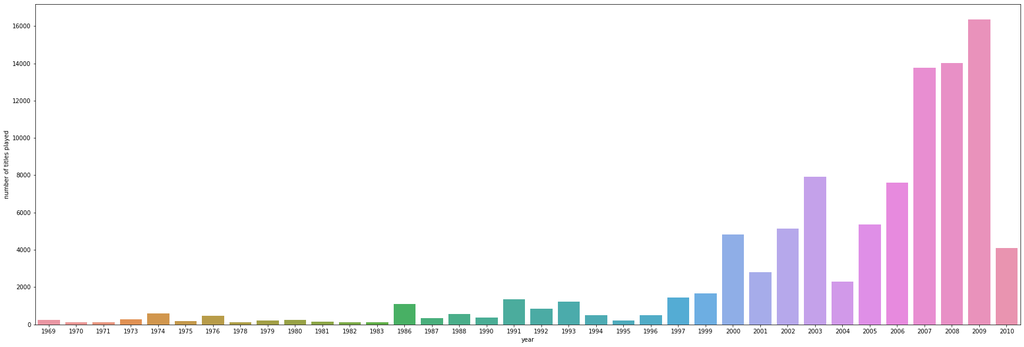

```python
# Create the plot

# Set the figure size
plt.figure(figsize = (30, 10))

sns.barplot(x = count.index,
            y = 'title',
            data = count,
            estimator = np.median)

# Set the y label of the plot
plt.ylabel('number of titles played')

# Show the plot
plt.show()
```

#### **Observations and Insights:**

- It looks like the **majority titles played were from year 2009 followed by 2008, 2007, 2003 and 2006**.
- The song titles from **1999 and before were hardly played compared to the newer years**.
- Numbers of titles played in the year 2003 was slightly more than 2006.
- We may or may not have enough data for the year 2010, so probably why it looks less popular.

**Think About It:** What other insights can be drawn using exploratory data analysis?

## **Proposed approach**

**Potential techniques:** What different techniques should be explored?

We can explore the below techniques for creating the recommendation systems.

- Popularity-Based Recommendation System
- User User Similarity-Based Collaborative Filtering recommendation system
- Item Item Similarity-based collaborative filtering recommendation system
- Model Based Collaborative Filtering - Matrix Factorization
- Cluster Based Recommendation System
- Content Based Recommendation Systems

**Overall solution design:** What is the potential solution design?

**Model 1: Popularity-Based Recommendation System**

- Popularity/Rank-based recommendation systems provide recommendations based on the most popular items. This kind of recommendation system is useful when we have cold start problems (when the user has no history in the dataset).
- To build the rank-based recommendation system, we take average of all the ratings provided to each song and then rank them based on their average rating.

**Model 2: Similarity/Neighborhood based Collaborative Filtering Based Recommendation System**

- In this type of recommendation system, we do not need any information about the users or items. We only need user-item interaction data to build a collaborative recommendation system.
- We use Surprise library here.
- In this we build a similarity based recommendation system using cosine similarity and using KNN to find similar users who are the nearest neighbor to the given user.
- We look at the performance of the model. In terms of how many recommendations are relevant and vice-versa, we check Precision@k, Recall@k, F1-Score@k to access the recommendation system.
- Once the baseline recommender is built, we can imrpove it by tuning its hyperparameters for the KNNBasic algorithms and find the RMSE for tuned user based collaborative filtering recommendation system.
- Then we build the final model by using tuned values of the hyperparameters, which we received by using grid search cross-validation. We check the RMSE again and comparte with the earlier model.
- We can find out the similar users to a given user or its nearest neighbors based on this KNNBasic algorithm, finding 5 most similar user to the user_id=1 and further Predicting the top 5 items for userId=1.

**Model 3: Item based Collaborative Filtering Recommendation System**

- We now look into similarity-based collaborative filtering where similarity is calculated between items, i.e. songs here.
- We use Surprise library here.
- We define similarity measure, nearest neighbour using KNNBasic algorithm. We observe the baseline model for RMSE, F_1 Score on the test set.
- We can try to improve the performance number by using GridSearchCV to tune different hyperparameters of this algorithm. (Performing 3-fold cross validation to tune the hyperparameters).
- At this point we build the final model by using optimal values of the hyperparameters which we received by using grid search cross-validation.
- We can also find out the similar items to a given item or its nearest neighbors based on this KNNBasic algorithm.
- We can find 5 most similar items to the song_id=1.
- We can also predict top 5 songs for user_id=1 with similarity based recommendation system.

**Model 4: Matrix Factorization**

- Model-based Collaborative Filtering is a personalized recommendation system. The recommendations are based on the past behavior of the user and it is not dependent on any additional information. We use latent features to find recommendations for each user.
- We use Surprise library here.
- SVD is used to compute the latent features from the user-item matrix. But SVD does not work when we miss values in the user-item matrix. We find predicted rating for user/song combination here.
- We can improve matrix factorization based recommendation system by tuning its 3 of it's hyperparameters. **n_epochs**(The number of iteration of the SGD algorithm), **lr_all** (The learning rate for all parameters), **reg_all**(The regularization term for all parameters).
- We build the final model by using optimal values of the hyperparameters which we received by using grid search cross-validation.
- We can now predict the rating for an user with user/song combination
- We can recommend the songs using the optimized svd model.

**Model 5: Cluster-Based Recommendation System**

- In clustering-based recommendation systems, we explore the similarities and differences in people's tastes in songs based on how they rate different songs. We cluster similar users together and recommend songs to a user based on ratings from other users in the same cluster.
- We use Surprise library here.
- We use CoClustering algorithm, check for RMSE, F1 Scores and predict the ratings for the user/song combinations.
- We can further improve clustering-based recommendation system by tuning its hyperparameters, **n_cltr_u (Number of user clusters), n_cltr_i (Number of item clusters), n_epochs (Number of iteration of the optimization loop), random_state, verbose**.
- We will build final model by using tuned values of the hyperparameters received after using the Grid search cross-validation.
- We now predict the rating for the user/song combinations and recommend songs.
- We also can implement the recommendation algorithm based on the optimized KNNBasic model
- We further correct the Ratings and Ranking of the above songs.

**Model 6: Content-Based Recommendation System**

- In a content-based recommendation system, we will use the feature - text, i.e.reviews to find similar movies. Text data generally contains pronunciation, stopwords, and non-ASCII characters, which makes it very noisy. So, we will first need to pre-process the text and then we will generate features from the text to compute similarities between the texts/reviews.
- We use nltk (natural language toolkit library) here.
- We merge/pre-process the data and need to use TF-IDF feature extraction technique to extract features, which we later use to compute similar songs based on these texts.
- Once we have extracted features from the text data using TF-IDF feature extraction, we can find similarities between songs using these features. We will use cosine similarity to calculate the similarity.
- Finally, we create a function to find the most similar songs to recommend for a given song.

**Measures of success:** What are the key measures of success to compare different potential technqiues?

- To evaluate the performance of the **Collaborative Filtering Based Recommendation System** models and **Cluster Based Recommendation System**, **Matrix Factorization**, precision@k and recall@k are used in this case study. Using these two metrics F_1 score is calculated for each working model. We can try to improve the performance of these models using hyperparameter tuning.
- We also evaluate RMSE which is a measure of error to check how far the overall predicted ratings are from the actual ratings.
- Popularity/Rank-based recommendation systems provide recommendations based on the most popular items. This kind of recommendation system is useful when we have cold start problems, i.e. new user.
- Content Based Recommendation system - If we want to base our recommendations entirly on the user's history, this recommendation works well.